# PA1_Template

Darryl Walker

December 24, 2018

# Reproducible Research Course Project 1

This analysis will study the number of steps taken by an anonymous individual, in five minute increments, during October-November 2012. The first step is to download the data:

```r
    if(!file.exists("./data")){dir.create("./data")}
    url <- "https://d396qusza40orc.cloudfront.net/repdata%2Fdata%2Factivity.zip"
    download.file(url, destfile = "./data/activity.zip")
    unzip("./data/activity.zip", exdir = "./data")
```

Now read the file into R:

```r
    activity1 <- read.csv("activity.csv", header = TRUE)
```

Looking at the data using the function, we see that there are three variables: steps, date, and interval. Steps and interval are integers which seem fine, but date is listed as a factor. We change it to a date variable with:

```r
    activity1$date <- as.Date(activity1$date, format = "%Y-%m-%d")
```

## What is the mean total number of steps taken per day?

This portion of the assignment requires calculating the total number of steps taken per day, plotting a histogram of total number of steps taken per day and reporting the mean and median of steps taken per day.

Total number of steps taken per day and the histogram is produced by:

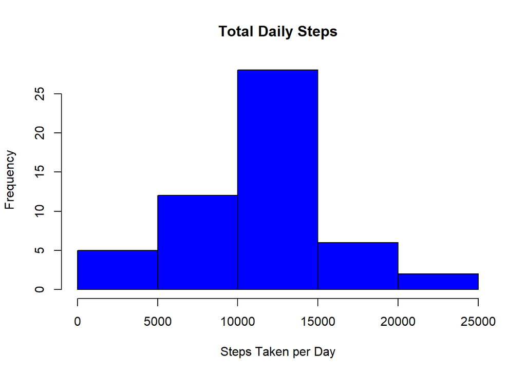

```r
    daysteps <- with(activity1, aggregate(steps ~ date, FUN = sum, na.rm = TRUE))
    daystats <- data.frame(Mean = mean(daysteps$steps), Median = median(daysteps$steps))
    hist(daysteps$steps, main = "Total Daily Steps", xlab = "Steps Taken per Day", col = "blue")
```

```r
    print(paste0("The average daily steps is ",daystats$Mean))
```

```
## [1] "The average daily steps is 10766.1886792453"
```

```r
    print(paste0("The median daily steps is ",daystats$Median))
```

```
## [1] "The median daily steps is 10765"
```

## What is the average daily activity pattern?

Here we are required to plot a time series of average steps taken during the five minute intervals and report on which interval has the highest average activity. Starting with finding the interval with the highest average activity:

```r
    intavgsteps <- with(activity1, aggregate(steps ~ interval, FUN = mean, na.rm = TRUE))
    maxint <- intavgsteps$interval[which.max(intavgsteps$steps)]
    print(paste0("The interval with the highest average activity is ",maxint))
```

```
## [1] "The interval with the highest average activity is 835"
```

The prior code shows that the highest activity is the 835 interval. For the plot, the following code does the trick:

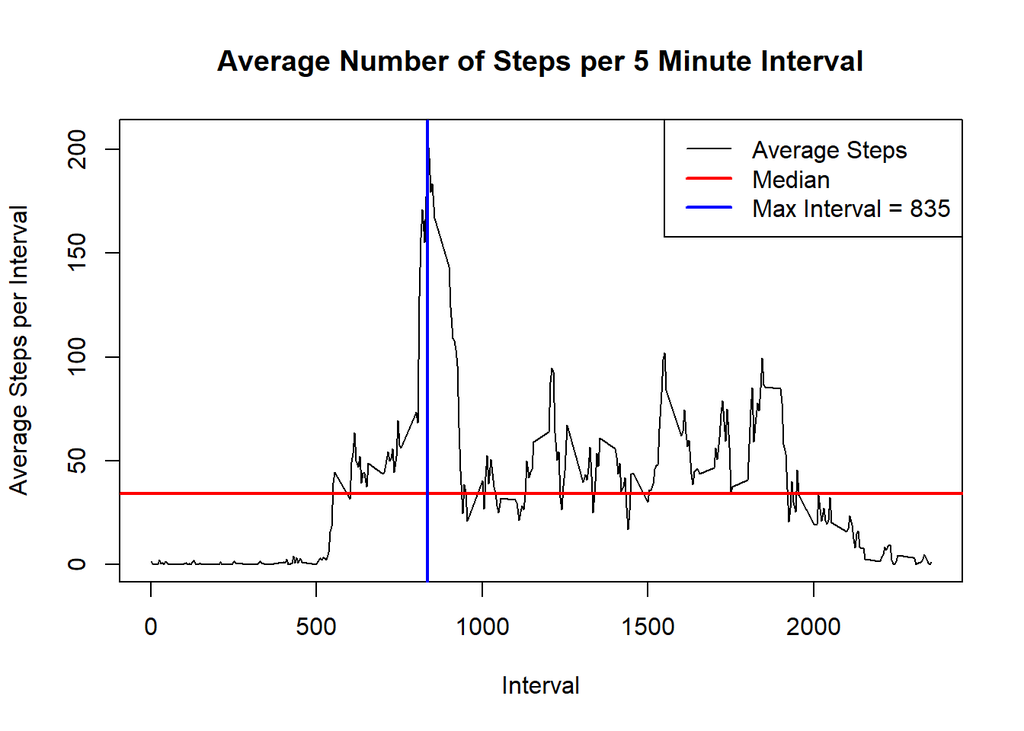

```r
    with(intavgsteps, plot(interval, steps, type = "l", xlab = "Interval", ylab = "Average Steps per Interval", main = "Average Number of Steps per 5 Minute Interval"))
    abline(h = median(intavgsteps$steps), col = "red", lwd = 2)
    abline(v = maxint, col = "blue", lwd = 2)
    legend("topright", legend = c("Average Steps", "Median", "Max Interval = 835"), col = c("black", "red",     "blue"),
    lty = 1:1, lwd = c(1,2,2))
```

The horizontal line is the median of the set of interval averages; the vertical line represents the interval with the highest steps activity.

## Imputing Missing Values

First, we have to calculate and report the number of missing values in the dataset:

```r
    missingsteps <- sum(is.na(activity1$steps))
    percMissStep <- mean(is.na(activity1$steps))
    print(paste0("The number of missing data points for steps is ", missingsteps))
```

```
## [1] "The number of missing data points for steps is 2304"
```

```r
    print(paste0("The percentage of missing data is ", round(percMissStep*100, digits = 2)))
```

```
## [1] "The percentage of missing data is 13.11"
```

Second, we will create a second identical data set and then replace the missing values with the overall average steps per interval

```r
    fullactivity <- activity1
    fullactivity$steps[which(is.na(activity1$steps))] <- mean(activity1$steps, na.rm = TRUE)
```

This last line of code is worth explaining. Calling is.na on the steps variable of the original data set creates a logical vector with TRUE for an NA value and FALSE otherwise. Calling which on that logical vector returns the index number where the values are TRUE. Since this index vector is enclosed in brackets, it is subsetting the fullactivity variable steps with the index numbers that are NA and assigning those indexed positions the mean of the steps variable in the original data set with the NA’s removed.

And now we create the histogram for the full data:

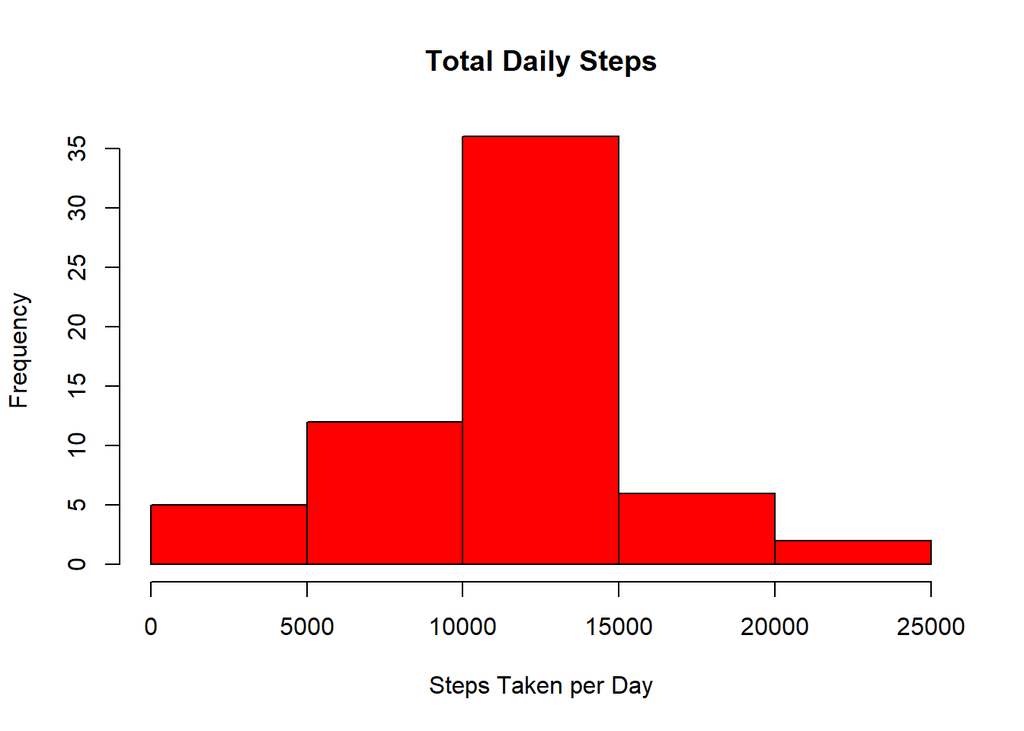

```r
    Fulldaysteps <- with(fullactivity, aggregate(steps ~ date, FUN = sum, na.rm = TRUE))
    hist(Fulldaysteps$steps, main = "Total Daily Steps", xlab = "Steps Taken per Day", col = "red")
```

```r
    fulldaystats <- data.frame(Mean = mean(Fulldaysteps$steps), Median = median(Fulldaysteps$steps))
    print(paste0("The average daily steps is ",fulldaystats$Mean))
```

```
## [1] "The average daily steps is 10766.1886792453"
```

```r
    print(paste0("The median daily steps is ",fulldaystats$Median))
```

```
## [1] "The median daily steps is 10766.1886792453"
```

As you can see, there is very little difference between the median and mean of the original data set and the data set with the imputed values. Since the mean was used as the replacing value, this is not surprising.

## Are there differences in activity patterns between weekdays and weekends?

Create a new factor variable named weekend with two levels–weekend or weekday and make a time series panel plot showing average steps per interval vs interval between Weekends and Weekdays. First, Create the factor variable weekend:

```r
    fullactivity$day <- weekdays(fullactivity$date, abbreviate = FALSE)
    fullactivity$weekend<- ifelse(fullactivity$day == "Saturday"|fullactivity$day == "Sunday",
       "Weekend", "Weekday")
```

And now aggregate the steps by interval and weekend and make the panel plot:

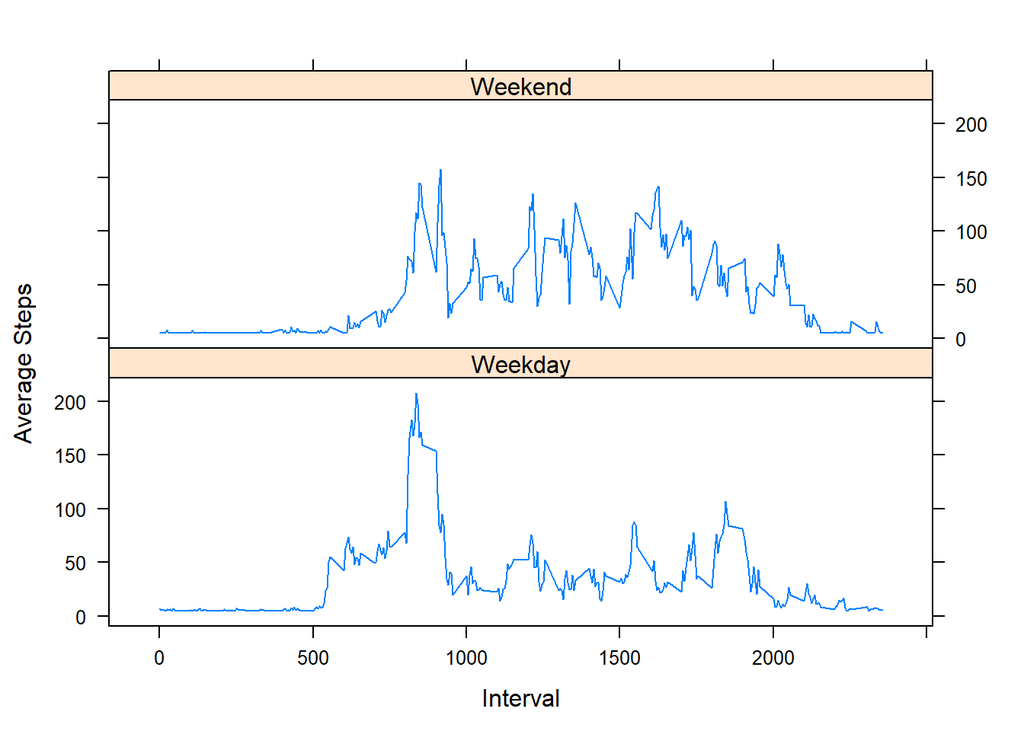

```r
    daytypesteps <- with(fullactivity, aggregate(steps ~ interval+weekend, FUN = mean))
    library(lattice)
    xyplot(steps ~ interval|weekend, data = daytypesteps, type = "l", ylab = "Average Steps",xlab = "Interval", layout = c(1,2))
```

The plot indicates that, although there is a spike in weekday activity around 835, the activity level is generally lower during the weekday versus the weekend.